# STAT 8090 Applied Mutlivariate Statistics Final Project: Classification of Vowel Sounds

```r
set.seed(1923)
##Get the test and training data together
simple_data=rbind(data_train[which(data_train$y %in% c(1,3,6,10)),],data_test[which(data_test$y %in% c(1,3,6,10)),])

## Hierarchical Clustering

dist_euc = dist(as.matrix(simple_data[,2:11]), "euclidean") #calculate distances
hc_euc_c= hclust(dist_euc, "complete") # Run hierarchical Clustering
hc_euc_c$height
```

```
##   [1] 0.08035546 0.09787747 0.10623559 0.11069779 0.11167811 0.11541664
##   [7] 0.11662333 0.13243867 0.13566134 0.14009640 0.14404860 0.14588009
##  [13] 0.14780392 0.14823292 0.14947241 0.14972308 0.15685343 0.15862850
##  [19] 0.15981239 0.16017490 0.16026852 0.16212341 0.17290749 0.17741759
##  [25] 0.17826385 0.17936834 0.18133946 0.18154063 0.18531325 0.18694384
##  [31] 0.18926172 0.19766639 0.20084073 0.20236601 0.20312312 0.20439178
##  [37] 0.20824025 0.20972363 0.21678100 0.22023624 0.22249719 0.22840315
##  [43] 0.22949946 0.23554617 0.23621812 0.23671079 0.23752684 0.23787181
##  [49] 0.23875929 0.24234686 0.24303086 0.24457719 0.25297035 0.25304743
##  [55] 0.25914668 0.26728262 0.26947356 0.26956261 0.27205330 0.27789746
##  [61] 0.28355070 0.28506841 0.28685014 0.28776379 0.29671030 0.29930085
##  [67] 0.30087871 0.30469001 0.30504590 0.30742316 0.30746382 0.30839099
##  [73] 0.30879929 0.30899515 0.31168734 0.31635897 0.31944170 0.32198758
##  [79] 0.32697095 0.32746603 0.32946472 0.33185087 0.33185238 0.33461321
##  [85] 0.33858972 0.33932433 0.34054221 0.34102346 0.34237991 0.34361024
```

[output cut: 45 more lines]

```r
plot(hc_euc_c,hang =-1, main="cluster for vowels",
     labels=as.factor(simple_data[,1]))
groups=cutree(hc_euc_c, k=4)
(groups)
```

```
##    1    3    6   10   12   14   17   21   23   25   28   32   34   36   39   43
##    1    1    1    2    1    1    1    2    1    1    1    2    1    1    1    2
##   45   47   50   54   56   58   61   65   67   69   72   76   78   80   83   87
##    1    1    1    2    1    1    1    2    3    1    1    2    3    1    1    2
##   89   91   94   98  100  102  105  109  111  113  116  120  122  124  127  131
##    3    1    1    2    3    1    1    2    3    1    1    2    3    1    1    2
##  133  135  138  142  144  146  149  153  155  157  160  164  166  168  171  175
##    1    1    1    2    1    1    1    2    1    1    1    2    1    1    1    2
##  177  179  182  186  188  190  193  197  199  201  204  208  210  212  215  219
##    1    1    1    2    1    1    1    2    1    1    1    2    1    1    1    2
##  221  223  226  230  232  234  237  241  243  245  248  252  254  256  259  263
##    1    1    1    2    1    1    1    2    1    1    1    2    1    1    1    2
##  265  267  270  274  276  278  281  285  287  289  292  296  298  300  303  307
##    3    3    1    4    3    3    1    4    3    3    1    4    3    3    1    4
##  309  311  314  318  320  322  325  329  331  333  336  340  342  344  347  351
```

[output cut: 31 more lines]

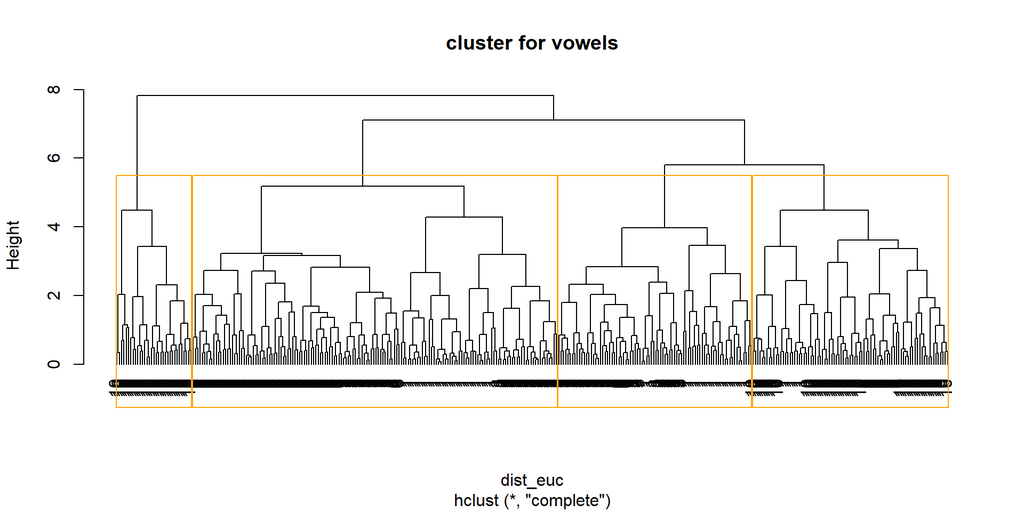

```r
rect.hclust(hc_euc_c, k=4,border="orange") #number of clusters is 4
```

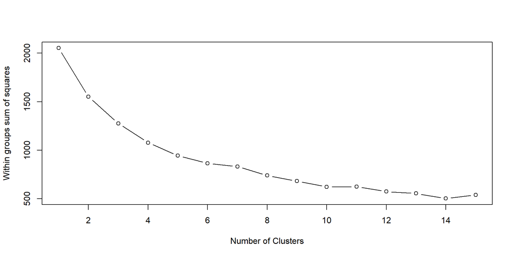

```r
## K Means Clustering

# Determine the optimum number of clusters(K)
wss <- (nrow(simple_data[,2:11])-1)*sum(apply(simple_data[,2:11],2,var))
for (i in 2:15) wss[i] <- sum(kmeans(simple_data[,2:11],
                                     centers=i)$withinss)
plot(1:15, wss, type="b", xlab="Number of Clusters",
     ylab="Within groups sum of squares")
```

```r
# K=4 seems feasible based on the elbow method.

clus_km = kmeans(simple_data[,2:11], 4,iter.max = 30) #Run kmeans clustering with K=4
clus_km
```

```
## K-means clustering with 4 clusters of sizes 70, 135, 52, 103
##
## Cluster means:
##         x.1          x.2         x.3       x.4         x.5       x.6
## 1 -4.650743 2.9052714286 -0.02475714 0.5486286 -0.13352857 0.4406143
## 2 -2.614378 1.6057111111 -0.66448148 0.3165704 -0.29337037 0.5858667
## 3 -2.357788 0.0007115385 -1.41263462 1.1302115 -0.08334615 1.7580769
## 4 -3.618437 0.6948349515  0.02517476 1.4504951  0.34901942 0.5439223
##           x.7        x.8        x.9       x.10
## 1 -0.05542857  0.3019286 -0.1345286 -0.3028429
## 2  0.06193333  0.3039111 -0.2514148 -0.1311630
## 3  0.13959615  0.8156731 -0.7762692 -0.5576346
## 4 -0.32957282 -0.4229417 -0.5301359  0.5116311
##
## Clustering vector:
```

[output cut: 55 more lines]

[figure not shown]

```r
plot(simple_data[,2:11], col=c(rep(1,90),rep(3,90),rep(6,90),rep(10,90)), main="true clusters")
```

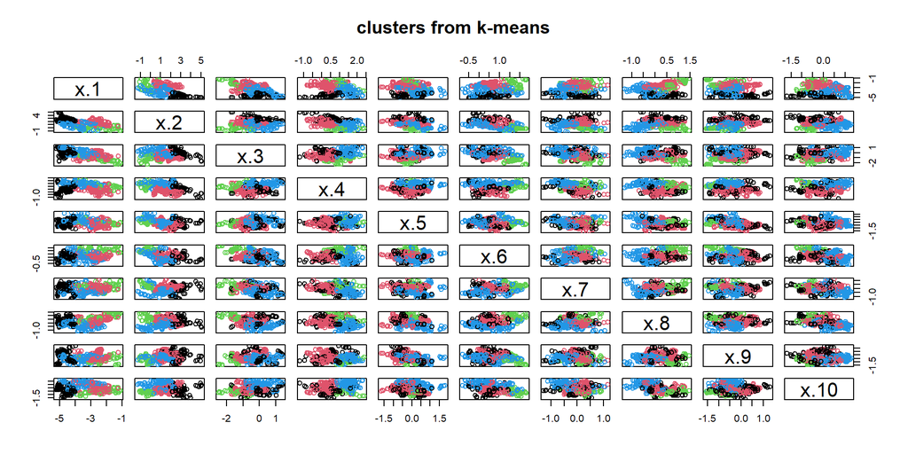

```r
plot(simple_data[,2:11], col = clus_km$cluster, main="clusters from k-means")
points(clus_km$centers, col = 1:4, pch = 8, cex=2)
```

```r
cluster_kmeans=clus_km$cluster

## Model Based Clustering
install.packages("mclust")
library(mclust)

mc = Mclust(simple_data[,2:11],G = 4) #Run model based clustering with number of clusters 4.
mc$parameters["mean"]
```

```
## $mean
##             [,1]        [,2]        [,3]        [,4]
## x.1  -2.59186562 -3.90349765 -3.64228876 -2.35692733
## x.2   0.44301682  2.63445810  0.92746411  1.27907316
## x.3  -1.26428923 -0.42168633  0.07265177 -0.46078281
## x.4   1.20524594  0.27881141  1.37229722  0.10698648
## x.5  -0.17396573 -0.36012651  0.32833753 -0.08714459
## x.6   1.55329253  0.53097448  0.38591619  0.58484058
## x.7   0.03719617  0.18692663 -0.39607010  0.03392484
## x.8   0.75967089  0.25581326 -0.41188508  0.37457195
## x.9  -0.61698678 -0.26111779 -0.52567570 -0.03681151
## x.10 -0.47516190 -0.08889929  0.52078198 -0.46902376
```

```r
summary(mc)
```

```
## ----------------------------------------------------
## Gaussian finite mixture model fitted by EM algorithm
## ----------------------------------------------------
##
## Mclust VEV (ellipsoidal, equal shape) model with 4 components:
##
##  log-likelihood   n  df       BIC       ICL
##       -2033.847 360 236 -5456.815 -5462.971
##
## Clustering table:
##   1   2   3   4
##  78 101 117  64
```

```r
cluster_model=mc$classification

"Among these results, the result of Kmeans clustering is easier for analysts to interpret. Hierarchical clustering is also good at displaying the results but for this number of classes, it is hard dto distinguish the labels. Model clustering is the one taking the most time to reach out to a result."
```

[output not shown]

```r
#Results of all of three analyses
cluster_hier=groups
cluster_hier
```

```
##    1    3    6   10   12   14   17   21   23   25   28   32   34   36   39   43
##    1    1    1    2    1    1    1    2    1    1    1    2    1    1    1    2
##   45   47   50   54   56   58   61   65   67   69   72   76   78   80   83   87
##    1    1    1    2    1    1    1    2    3    1    1    2    3    1    1    2
##   89   91   94   98  100  102  105  109  111  113  116  120  122  124  127  131
##    3    1    1    2    3    1    1    2    3    1    1    2    3    1    1    2
##  133  135  138  142  144  146  149  153  155  157  160  164  166  168  171  175
##    1    1    1    2    1    1    1    2    1    1    1    2    1    1    1    2
##  177  179  182  186  188  190  193  197  199  201  204  208  210  212  215  219
##    1    1    1    2    1    1    1    2    1    1    1    2    1    1    1    2
##  221  223  226  230  232  234  237  241  243  245  248  252  254  256  259  263
##    1    1    1    2    1    1    1    2    1    1    1    2    1    1    1    2
##  265  267  270  274  276  278  281  285  287  289  292  296  298  300  303  307
##    3    3    1    4    3    3    1    4    3    3    1    4    3    3    1    4
##  309  311  314  318  320  322  325  329  331  333  336  340  342  344  347  351
```

[output cut: 31 more lines]

```r
cluster_kmeans
```

```
##    1    3    6   10   12   14   17   21   23   25   28   32   34   36   39   43
##    3    3    2    2    3    3    2    2    3    3    2    2    3    3    2    2
##   45   47   50   54   56   58   61   65   67   69   72   76   78   80   83   87
##    3    3    2    2    3    3    2    2    4    2    2    1    4    2    2    1
##   89   91   94   98  100  102  105  109  111  113  116  120  122  124  127  131
##    4    2    2    1    4    2    2    1    4    2    2    1    4    2    2    1
##  133  135  138  142  144  146  149  153  155  157  160  164  166  168  171  175
##    3    3    2    1    3    3    2    1    3    3    2    1    3    3    2    1
##  177  179  182  186  188  190  193  197  199  201  204  208  210  212  215  219
##    3    3    2    1    3    3    2    1    3    2    2    2    3    2    2    2
##  221  223  226  230  232  234  237  241  243  245  248  252  254  256  259  263
##    3    2    2    2    3    2    2    1    3    2    2    1    3    2    2    1
##  265  267  270  274  276  278  281  285  287  289  292  296  298  300  303  307
##    4    4    2    1    4    4    2    1    4    4    2    1    4    4    2    1
##  309  311  314  318  320  322  325  329  331  333  336  340  342  344  347  351
```

[output cut: 31 more lines]

```r
cluster_model
```

```
##    1    3    6   10   12   14   17   21   23   25   28   32   34   36   39   43
##    1    1    2    1    1    1    2    1    1    1    2    1    1    1    2    1
##   45   47   50   54   56   58   61   65   67   69   72   76   78   80   83   87
##    1    1    2    1    1    1    2    1    3    4    4    2    3    4    4    2
##   89   91   94   98  100  102  105  109  111  113  116  120  122  124  127  131
##    3    4    4    2    3    4    4    2    3    4    4    2    3    4    4    2
##  133  135  138  142  144  146  149  153  155  157  160  164  166  168  171  175
##    1    1    1    2    1    1    1    2    1    1    1    2    1    1    1    2
##  177  179  182  186  188  190  193  197  199  201  204  208  210  212  215  219
##    1    1    1    2    1    1    1    2    1    4    4    2    1    4    4    2
##  221  223  226  230  232  234  237  241  243  245  248  252  254  256  259  263
##    1    4    4    2    1    4    4    2    1    4    4    2    1    4    4    2
##  265  267  270  274  276  278  281  285  287  289  292  296  298  300  303  307
##    3    3    2    2    3    3    2    2    3    3    2    2    3    3    2    2
##  309  311  314  318  320  322  325  329  331  333  336  340  342  344  347  351
```

[output cut: 31 more lines]

```r
##Compare the clustering models

comparison_hier=adjustedRandIndex(simple_data$y,cluster_hier)
comparison_kmeans=adjustedRandIndex(simple_data$y,cluster_kmeans)
comparison_model=adjustedRandIndex(simple_data$y,cluster_model)

##AdjustedRandIndex Comparison Table
cbind.data.frame(comparison_hier,comparison_kmeans,comparison_model)
```

```
##   comparison_hier comparison_kmeans comparison_model
## 1       0.2397214         0.3850257        0.2186533
```

```r
"AdjustedRandIndex is a kind of metric indicating the accuracy of the clustering model in terms of comparing true labels with the assigned labels.Based on the results, the best model is the kmeans model with 30 iteration and 4 clusters with 0.39 AdjustedRandIndex. Hierarchical clustering follows the kmeans model with an AdjustedRandIndex of 0.24. The least successful model is the model based clustering with an AdjustedRandIndex of 0.22. Considering its interpreting advantages, K means model works better in clustering the vowel sounds limited to classes of 1,3,6, and 10."
```

[output not shown]

## 7. What is the final conclusion based on the previous methods?

**ANSWER**

For the original data set, QDA gives a lower misclassification rate in comparison with the LDA. PCA analyses before running QDA or LDA worsen the performance of LDA and QDA. That can be interpreted that a small portion of the total variance (recall we dismissed the least important 10% part of the total variance ) plays a vital role in classification.

After removing classes that are the hardest to distinguish, we see an important improvement in especially LDA’s performance. WE can conclude that after removing those classes, building linear relations and classification based on that get easier. However, running PCA before QDA and LDA again ended up with high error rates. But this time, LDA seems affected much worse than QDA. We can interpret this result like loss of information damages LDA seriously.

In the alternative analyses that classes are removed for the purpose of reducing ambiguity in the data, we see PCA works much better with both LDA and QDA.

I wanted to recall that all these final interpretations are made based on the error rates for test data sets. It is obvious that there is an overfitting problem in the results of training parts.

Finally, in clustering analysis, in the Kmeans method cluster number is decided as 4, based on the elbow method, and to avoid any bias in comparison to different methods, the cluster number is kept the same as 4. Finally, for classes of 1,3,6, and 10, the K-means clustering method performs much better with adjustedRandIndex 0.39 than the hierarchical and model-based clustering method. To empower the algorithm learning, the training data set and test data set are merged at the beginning of the clustering analysis part.